# Microbial community profiling

Mark N. Read

17/04/2019

```r
rm(list=ls())  # Clean environment

knitr::opts_chunk$set(echo = TRUE)

library(phyloseq)
library(vegan)  # Adonis function.
require(gtools)  # Mixedsort
```

```r
library(ggplot2)
library(stats)

# Change this if you attept to run from another location.
working_directory = '/Users/markread/dropbox_usyd/projects/henstridge/5.phyloseq/'
setwd(working_directory)  # If running individual chunks from within R
knitr::opts_chunk$set(root.dir = working_directory)  # If compiling Rmd documnet through Knit.

source('../commons.R')
source('../microbial_ecology_tools/microbial_ecology_functions.R')
```

[output not shown]

```r
theme_set(theme_grey())  # Color scheme for ggplot2
```

```r
seq_table = read.table('../4.dada2/seqtab-nochim.txt',
                       check.names=FALSE)  # Not checking names because samples begin with numbers.
otu_tab = otu_table(seq_table, taxa_are_rows=TRUE)
# Sanity check
dim(otu_tab)
```

```
## [1] 1082   80
```

```r
colnames(otu_tab)
```

```
##  [1] "69_pre"       "73_post"      "74_pre"       "74_post"
##  [5] "75_pre"       "75_post"      "76_pre"       "76_post"
##  [9] "77_pre"       "77_post"      "78_pre"       "69_post"
## [13] "78_post"      "79_pre"       "79_post"      "80_pre"
## [17] "80_post"      "81_pre"       "81_post"      "82_pre"
## [21] "82_post"      "83_pre"       "70_pre"       "83_post"
## [25] "84_pre"       "84_post"      "85_pre"       "85_post"
## [29] "86_pre"       "86_post"      "87_pre"       "87_post"
## [33] "88_pre"       "70_post"      "88_post"      "89_pre"
## [37] "89_post"      "90_pre"       "90_post"      "91_pre"
## [41] "91_post"      "92_pre"       "92_post"      "93_pre"
## [45] "71_pre"       "93_post"      "94_pre"       "94_post"
## [49] "95_pre"       "95_post"      "96_pre"       "96_post"
## [53] "97_pre"       "97_post"      "98_pre"       "71_post"
## [57] "98_post"      "99_pre"       "99_post"      "100_pre"
## [61] "100_post"     "101_pre"      "101_post"     "102_pre"
## [65] "102_post"     "69_pre_dup"   "72_pre"       "69_post_dup"
## [69] "72_pre_dup"   "72_post_dup"  "85_pre_dup"   "85_post_dup"
## [73] "90_pre_dup"   "90_post_dup"  "97_pre_dup"   "97_post_dup"
## [77] "100_pre_dup"  "72_post"      "100_post_dup" "73_pre"
```

```r
# Import taxonomy table. Cross-references "otus" (sequences if from dada2) with taxonomic determination.
tax_mat = read.table('../4.dada2/seqs_taxonomy.txt', row.names=1, sep=',', check.names=FALSE,
                     colClasses="character")  # Don't convert strings to factors.
tax_mat = as.matrix(tax_mat)  # Conversion needed by phyloseq.
dim(tax_mat)  # Sanity check
```

```
## [1] 1082    7
```

```r
colnames(tax_mat)
```

```
## [1] "Kingdom" "Phylum"  "Class"   "Order"   "Family"  "Genus"   "Species"
```

```r
typeof(tax_mat)  # Should be "character"
```

```
## [1] "character"
```

```r
tax_tab = tax_table(tax_mat)  # Convert to phyloseq object


# Import mapping file
metadata_tab = read.table("../mapping_file.txt", check.names=FALSE, header=TRUE, sep='\t',
                          colClasses="character",  # Don't convert strings to factors.
                          # First header line starts with '#' for qiime compatibiity. Don't ignore, so set to nonsensical value
                          comment.char='^')
metadata_tab = as.data.frame(metadata_tab)  # Conversion needed by phyloseq.
rownames(metadata_tab) <- metadata_tab$Sample
metadata_tab$Donor = factor(metadata_tab$Donor, ordered = TRUE, levels = c('NC_Sed', 'NC_Ex', 'HF_Sed', 'HF_Ex'))
# Sanity check
dim(metadata_tab)
```

```
## [1] 80 15
```

```r
colnames(metadata_tab)
```

```
##  [1] "#SampleID"            "BarcodeSequence"      "LinkerPrimerSequence"
##  [4] "InputFileName"        "IlluminaID"           "SortOrder"
##  [7] "Sample"               "Mouse"                "SampleTime"
## [10] "Duplicate"            "Donor"                "DonorDiet"
## [13] "DonorActivity"        "Description"          "DuplicatedSample"
```

```r
metadata_df = sample_data(metadata_tab)


# Build a phyloseq object.
sample_names(otu_tab)  # Sanity check
```

```
##  [1] "69_pre"       "73_post"      "74_pre"       "74_post"
##  [5] "75_pre"       "75_post"      "76_pre"       "76_post"
##  [9] "77_pre"       "77_post"      "78_pre"       "69_post"
## [13] "78_post"      "79_pre"       "79_post"      "80_pre"
## [17] "80_post"      "81_pre"       "81_post"      "82_pre"
## [21] "82_post"      "83_pre"       "70_pre"       "83_post"
## [25] "84_pre"       "84_post"      "85_pre"       "85_post"
## [29] "86_pre"       "86_post"      "87_pre"       "87_post"
## [33] "88_pre"       "70_post"      "88_post"      "89_pre"
## [37] "89_post"      "90_pre"       "90_post"      "91_pre"
## [41] "91_post"      "92_pre"       "92_post"      "93_pre"
## [45] "71_pre"       "93_post"      "94_pre"       "94_post"
## [49] "95_pre"       "95_post"      "96_pre"       "96_post"
## [53] "97_pre"       "97_post"      "98_pre"       "71_post"
## [57] "98_post"      "99_pre"       "99_post"      "100_pre"
## [61] "100_post"     "101_pre"      "101_post"     "102_pre"
## [65] "102_post"     "69_pre_dup"   "72_pre"       "69_post_dup"
## [69] "72_pre_dup"   "72_post_dup"  "85_pre_dup"   "85_post_dup"
## [73] "90_pre_dup"   "90_post_dup"  "97_pre_dup"   "97_post_dup"
## [77] "100_pre_dup"  "72_post"      "100_post_dup" "73_pre"
```

```r
sample_names(metadata_df)
```

```
##  [1] "69_post"      "73_post"      "77_post"      "81_post"
##  [5] "85_post"      "94_post"      "96_post"      "69_post_dup"
##  [9] "85_post_dup"  "72_post"      "76_post"      "80_post"
## [13] "84_post"      "90_post"      "95_post"      "97_post"
## [17] "100_post"     "101_post"     "72_post_dup"  "90_post_dup"
## [21] "97_post_dup"  "100_post_dup" "71_post"      "75_post"
## [25] "79_post"      "83_post"      "87_post"      "89_post"
## [29] "92_post"      "99_post"      "70_post"      "74_post"
## [33] "78_post"      "82_post"      "86_post"      "88_post"
## [37] "91_post"      "93_post"      "98_post"      "102_post"
## [41] "70_pre"       "74_pre"       "78_pre"       "82_pre"
## [45] "86_pre"       "88_pre"       "91_pre"       "93_pre"
## [49] "98_pre"       "102_pre"      "71_pre"       "75_pre"
## [53] "79_pre"       "83_pre"       "87_pre"       "89_pre"
## [57] "92_pre"       "99_pre"       "72_pre"       "76_pre"
## [61] "80_pre"       "84_pre"       "90_pre"       "95_pre"
## [65] "97_pre"       "100_pre"      "101_pre"      "72_pre_dup"
## [69] "90_pre_dup"   "97_pre_dup"   "100_pre_dup"  "69_pre"
## [73] "73_pre"       "77_pre"       "81_pre"       "85_pre"
## [77] "94_pre"       "96_pre"       "69_pre_dup"   "85_pre_dup"
```

```r
phylo = phyloseq(otu_tab, tax_tab, metadata_df)

# Filter into pre-gavage and post-gavage samples
phylo_pre = subset_samples(phylo, SampleTime=='pre')
phylo_post = subset_samples(phylo, SampleTime=='post')
# Exclude duplicates from analysis - they are technical replicates of the same animals, and we do not wish to bias
# the analysis by including the same animal twice.
phylo_post = subset_samples(phylo_post, Duplicate=='No')
```

# 1 Verify no significant difference in sequencing depth per group

We wish to attribute any changes observed between samples to the donor group. It is therefore important to rule out differences in sequencing depth (number of sequences obtained per experimental group) as a potential confounding factor. The box plot and permanova confirm sequencing depth cannot be attributed to donor group.

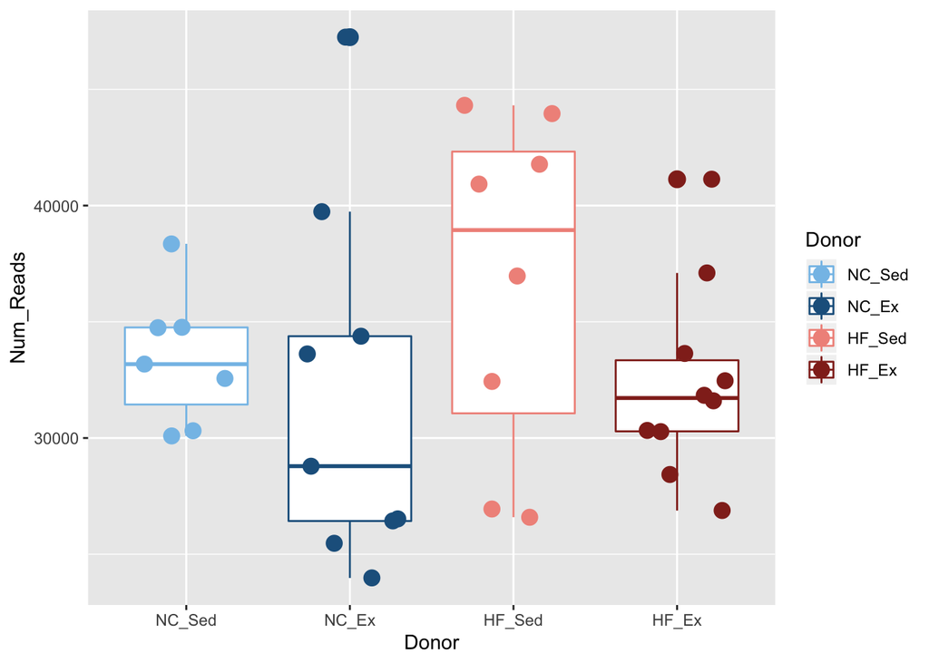

```r
# =================
# Check that sampling depth (number of OTU reads recorded for each sample) does not differ between groups
Num_Reads = colSums(otu_table(phylo_post))
Sample = sample_data(phylo_post)$Sample
Donor = sample_data(phylo_post)$Donor
sample_depth_df = data.frame(Sample, Donor, Num_Reads)

# Plot with series annotated
p = ggplot(sample_depth_df, aes(x=Donor, y=Num_Reads, color=Donor)) +
  geom_boxplot(outlier.size=NA) +  # Turn off outliers, as we plot each datapoint below.
  scale_colour_manual(values=col_per_group) +
  geom_jitter(shape=16, position=position_jitter(0.3), size=4)
ggsave("post_gavage_sampling_depth_Donor_ANNOTATED.pdf")
print(p)
```

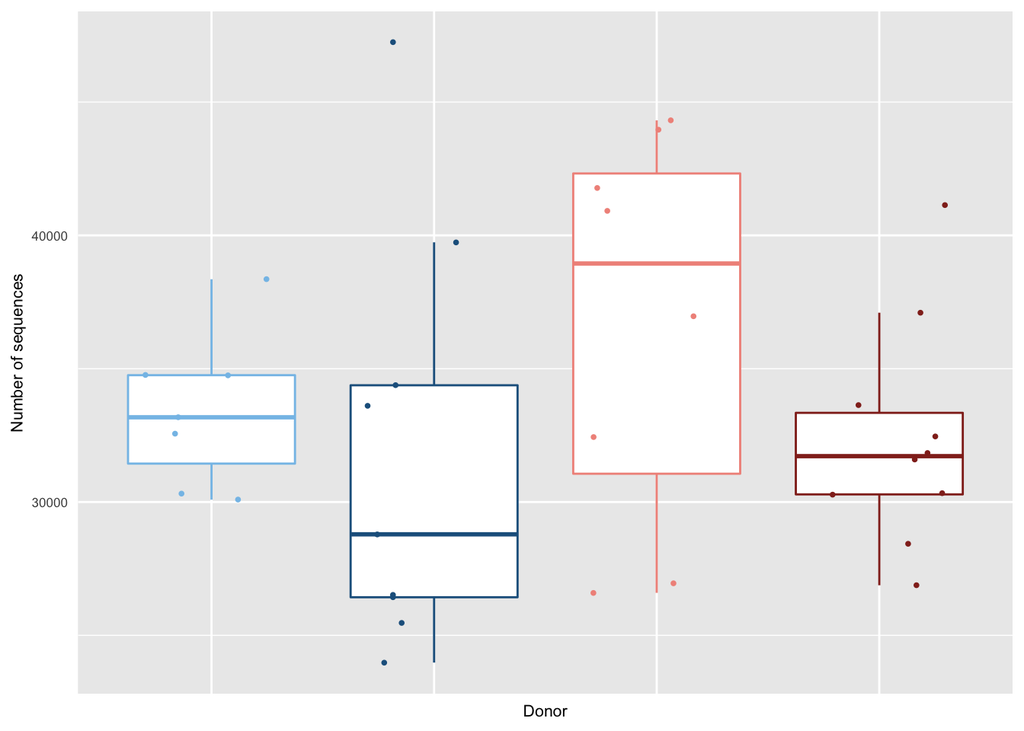

```r
# Plot for publication.
p = ggplot(sample_depth_df, aes(x=Donor, y=Num_Reads, color=Donor)) +
    geom_boxplot(outlier.shape = NA) +  # Turn off outliers, as we plot each datapoint below.
    scale_colour_manual(values=col_per_group) +
    geom_jitter(shape=16, position=position_jitter(0.3), size=1) +
    ylab('Number of sequences') +
    theme(text = element_text(size=8),
          legend.position="none",
          axis.ticks = element_blank(),  # Turn off black tick marks.
          axis.text.x = element_blank()  # Turn off tick label titles.
          )
ggsave("post_gavage_sampling_depth_Donor.pdf", height=50, width=60, units='mm')
print(p)
```

```r
# Check significance.
# Adonis is a stochastic algorithm.
# Ensure consistent results. I've checked multiple different seeds, result is consistently statistically insignificant.
set.seed(999)
adonis(Num_Reads ~ Donor, data=sample_depth_df, method="euclidean")  # performs a permanova.
```

```
##
## Call:
## adonis(formula = Num_Reads ~ Donor, data = sample_depth_df, method = "euclidean")
##
## Permutation: free
## Number of permutations: 999
##
## Terms added sequentially (first to last)
##
##           Df  SumsOfSqs  MeanSqs F.Model      R2 Pr(>F)
## Donor      3  122873548 40957849  1.1661 0.10443  0.338
## Residuals 30 1053690702 35123023         0.89557
## Total     33 1176564251                  1.00000
```

```r
sink("post_gavage_sampling_depth_Donor_permanova.txt")  # Write to file.
print(adonis(Num_Reads ~ Donor, data=sample_depth_df, method="euclidean"))
```

```
##
## Call:
## adonis(formula = Num_Reads ~ Donor, data = sample_depth_df, method = "euclidean")
##
## Permutation: free
## Number of permutations: 999
##
## Terms added sequentially (first to last)
##
##           Df  SumsOfSqs  MeanSqs F.Model      R2 Pr(>F)
## Donor      3  122873548 40957849  1.1661 0.10443  0.357
## Residuals 30 1053690702 35123023         0.89557
## Total     33 1176564251                  1.00000
```

```r
sink()
```

# 2 Sequencing depth was sufficient to identify all major taxa present

Another potential confounding factor is if the sequencing depth was not a sufficient sampling of all microbes in the environment. If we did not sequence deep enough, then it is possible that observed differences between groups could stem from not observing microbes *that were in fact present had we only looked deeper*. We test this by sub-sampling each sample and counting how the number of unique taxa identified grows with the number of sequences identified. We hope to observe a plateau, through which we can argue that further sampling would not have yielded any previously unobserved microbes.

We find that each sample achieves a plateau.

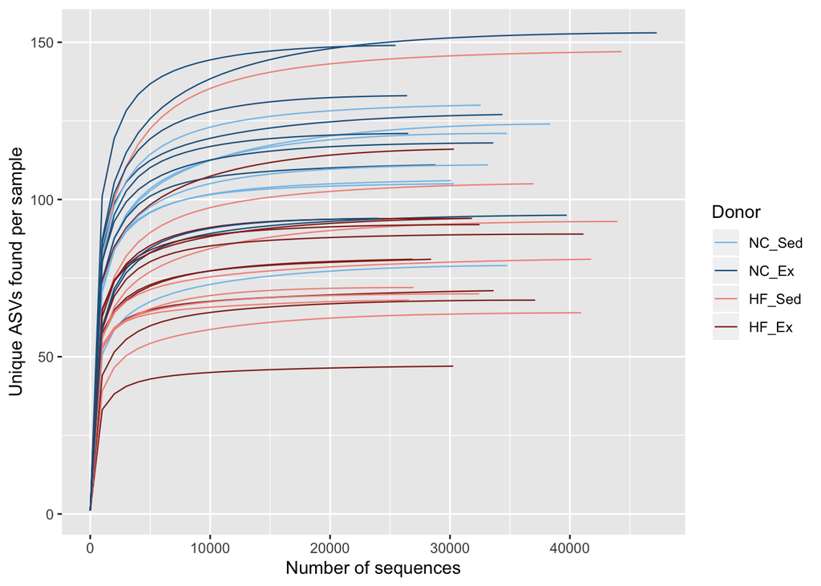

```r
# =================
# Rarefaction curves. Check that we aren't sub-sampling to the point of missing OTUs/sequences.
source('../microbial_ecology_tools/ggrare.R')
p = ggrare(phylo_post, step = 1000, line_weight=0.4,
           label= NULL, # 'Sample',
           color='Donor', col_per_group = col_per_group, plot = TRUE, parallel = TRUE, se = FALSE)
```

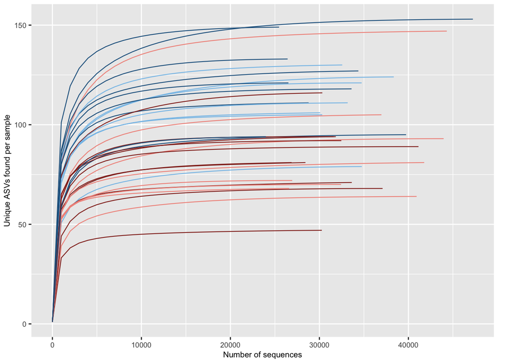

```r
p = p + theme(text = element_text(size=9))
ggsave("post_gavage_rarefaction_curves-ANNOTEATED.pdf")
# Plot for publication.
p = p +
    theme(legend.position="none", text = element_text(size=9), axis.title = element_text(size=8)) +
    theme(plot.margin=margin(t = 4, r = 15, b = 4, l = 4, unit = "pt"))  # Add a bit of extra whitespace on right.
p
```

```r
ggsave("post_gavage_rarefaction_curves.pdf", height=50, width=60, units='mm')
```

# 3 Alpha diversity analyses

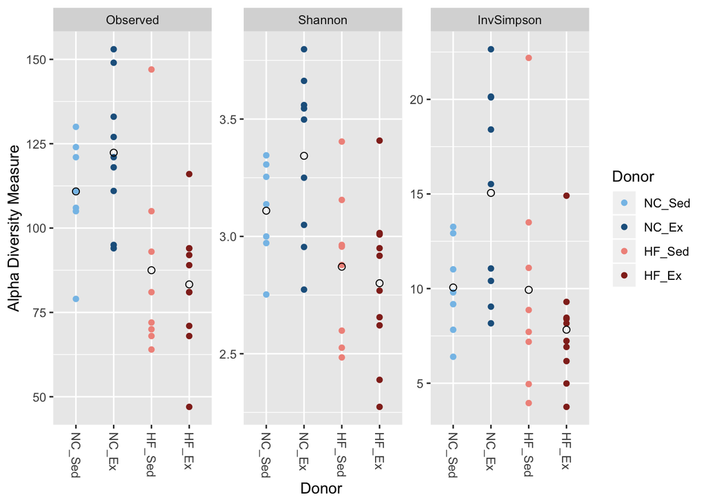

```r
# Change the order of samples to group by Donor.
sd = sample_data(phylo_post)
sd =
sorted_sd = sd[order(as.numeric(sd$SortOrder)), ]  # Ordered by SortOrder
desired_col_order = rownames(sorted_sd)

# Plot richness
p = plot_richness(phylo_post, measures=c("Observed","Shannon","InvSimpson"), color="Donor", x='Donor') +
    stat_summary(  # Plot means.
    geom = "point",
    fun.y = "mean",
    col = "black",
    size = 2,
    shape = 1,
    fill = NA
    ) +
    scale_shape(solid = FALSE) +
    scale_colour_manual(values=col_per_group)
# Change the order of the samples on the x axis to be listed by experimental group. This was manually determined in the mapping file: "SortOrder"
p$data$sample = as.character(p$data$samples)  # "Sample" here is data-set specific. It's the dataframe column being plotted on X
p$data$sample = factor(p$data$samples, levels=desired_col_order)
# p = p + geom_boxplot(outler.shape = NA, shape=NA) +
        #geom_point(size=1.0, shape=21, fill=NA)
p
```

```r
ggsave("post_gavage_alpha_diversity-ANNOTATED.pdf", width=15, height=7)  # Adjust the width of the saved plot, stop sample IDs being squeezed.
# Plot for publication.
p = p + theme(legend.position="none",
              axis.text.x = element_blank(),  # Turn off tick label titles.
              axis.ticks = element_blank(),  # Turn off black tick marks.
              text = element_text(size=9),
              axis.title = element_text(size=8),
              axis.title.x = element_blank()  # Turn off x axis label.
              ) +
    scale_colour_manual(values=col_per_group)
```

[output not shown]

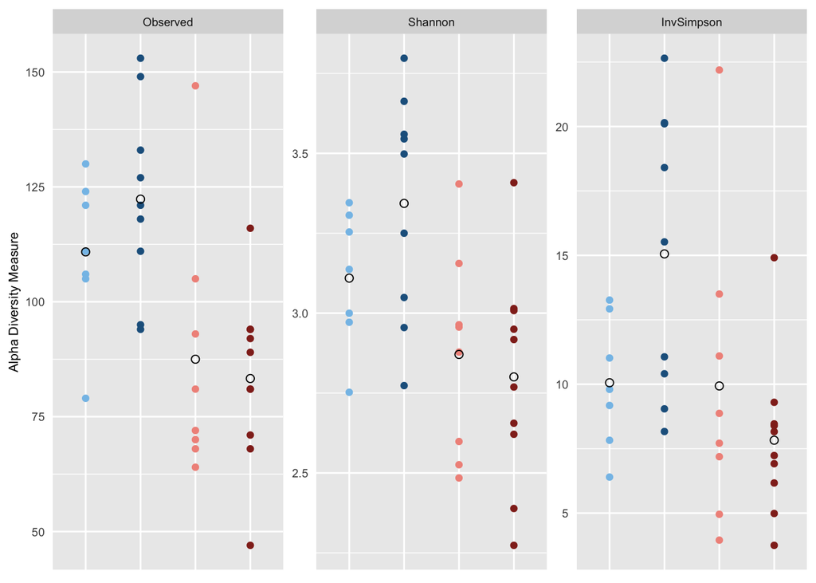

```r
p
```

```r
ggsave("post_gavage_alpha_diversity.pdf", width=70, height=40, units='mm')

#### Is there any statistically significant difference between groups based on alpha diversity?
# Ignore the warning about singletons - pretty sure this is because we use DADA2 which doesn't produce as many
# singletons as previous technologioes.
# Returns data frame (and renames samples starting with numbers), but preserves order of input data.
richness = estimate_richness(phylo_post)  # Actually used in the plot_richness function above. Same data.
richness$Donor = sample_data(phylo_post)$Donor  # Add a column?s

# Perform a PERMANOVA to seek statistically significant differences in groups, in terms of alpha diversity.
# This does not say which groups are different, only if there are differences.
adonis(Observed ~ Donor, data=richness, method="euclidean")  # Print to the notebook.
```

```
##
## Call:
## adonis(formula = Observed ~ Donor, data = richness, method = "euclidean")
##
## Permutation: free
## Number of permutations: 999
##
## Terms added sequentially (first to last)
##
##           Df SumsOfSqs MeanSqs F.Model      R2 Pr(>F)
## Donor      3    9350.1  3116.7  6.8155 0.40531  0.001 ***
## Residuals 30   13719.0   457.3         0.59469
## Total     33   23069.1                 1.00000
## ---
## Signif. codes:  0 '***' 0.001 '**' 0.01 '*' 0.05 '.' 0.1 ' ' 1
```

```r
adonis(Shannon ~ Donor, data=richness, method="euclidean")  # Print to the notebook.
```

```
##
## Call:
## adonis(formula = Shannon ~ Donor, data = richness, method = "euclidean")
##
## Permutation: free
## Number of permutations: 999
##
## Terms added sequentially (first to last)
##
##           Df SumsOfSqs MeanSqs F.Model      R2 Pr(>F)
## Donor      3    1.6562 0.55206  5.5484 0.35685  0.005 **
## Residuals 30    2.9850 0.09950         0.64315
## Total     33    4.6412                 1.00000
## ---
## Signif. codes:  0 '***' 0.001 '**' 0.01 '*' 0.05 '.' 0.1 ' ' 1
```

```r
adonis(InvSimpson ~ Donor, data=richness, method="euclidean")  # Print to the notebook.
```

```
##
## Call:
## adonis(formula = InvSimpson ~ Donor, data = richness, method = "euclidean")
##
## Permutation: free
## Number of permutations: 999
##
## Terms added sequentially (first to last)
##
##           Df SumsOfSqs MeanSqs F.Model      R2 Pr(>F)
## Donor      3    260.89  86.963  4.3442 0.30286  0.009 **
## Residuals 30    600.54  20.018         0.69714
## Total     33    861.42                 1.00000
## ---
## Signif. codes:  0 '***' 0.001 '**' 0.01 '*' 0.05 '.' 0.1 ' ' 1
```

```r
# Repeat, but save to file system.
sink('post_gavage_alpha_diversity_permanova.txt')
cat('Observed taxa\n')
```

```
## Observed taxa
```

```r
adonis(Observed ~ Donor, data=richness, method="euclidean")  # Print to the notebook.
```

```
##
## Call:
## adonis(formula = Observed ~ Donor, data = richness, method = "euclidean")
##
## Permutation: free
## Number of permutations: 999
##
## Terms added sequentially (first to last)
##
##           Df SumsOfSqs MeanSqs F.Model      R2 Pr(>F)
## Donor      3    9350.1  3116.7  6.8155 0.40531  0.003 **
## Residuals 30   13719.0   457.3         0.59469
## Total     33   23069.1                 1.00000
## ---
## Signif. codes:  0 '***' 0.001 '**' 0.01 '*' 0.05 '.' 0.1 ' ' 1
```

```r
cat('\n\nShannon taxa\n')
```

```
##
##
## Shannon taxa
```

```r
adonis(Shannon ~ Donor, data=richness, method="euclidean")  # Print to the notebook.
```

```
##
## Call:
## adonis(formula = Shannon ~ Donor, data = richness, method = "euclidean")
##
## Permutation: free
## Number of permutations: 999
##
## Terms added sequentially (first to last)
##
##           Df SumsOfSqs MeanSqs F.Model      R2 Pr(>F)
## Donor      3    1.6562 0.55206  5.5484 0.35685  0.005 **
## Residuals 30    2.9850 0.09950         0.64315
## Total     33    4.6412                 1.00000
## ---
## Signif. codes:  0 '***' 0.001 '**' 0.01 '*' 0.05 '.' 0.1 ' ' 1
```

```r
cat('\n\nInverse Simpson taxa\n')
```

```
##
##
## Inverse Simpson taxa
```

```r
adonis(InvSimpson ~ Donor, data=richness, method="euclidean")  # Print to the notebook.
```

```
##
## Call:
## adonis(formula = InvSimpson ~ Donor, data = richness, method = "euclidean")
##
## Permutation: free
## Number of permutations: 999
##
## Terms added sequentially (first to last)
##
##           Df SumsOfSqs MeanSqs F.Model      R2 Pr(>F)
## Donor      3    260.89  86.963  4.3442 0.30286  0.011 *
## Residuals 30    600.54  20.018         0.69714
## Total     33    861.42                 1.00000
## ---
## Signif. codes:  0 '***' 0.001 '**' 0.01 '*' 0.05 '.' 0.1 ' ' 1
```

```r
sink()
```

We found statistically significant differences between groups. Seek now which groups those differences arise from. Writes to file.

```r
stat = function(metric, group1_label, group2_label) {
  group1 = richness[richness$Donor == group1_label, metric]
  group2 = richness[richness$Donor == group2_label, metric]
  ks = ks.test(x=group1, y=group2, alternative='two.sided')
  pval = round(ks$p.value, digits=3)  # Three decimal places.
  if (pval < 0.05 | TRUE) {
    print(paste(metric, ':', group1_label, 'vs', group2_label, '=',
                pval,
                ' - KS test, two sided', sep=' '))
  }
}

sink('post_gavage_alpha_diversity_statistics.txt')
for (metric in c('Observed', 'Shannon', 'InvSimpson')) {
  stat(metric, 'HF_Ex', 'HF_Sed')
  stat(metric, 'HF_Ex', 'NC_Ex')
  stat(metric, 'HF_Ex', 'NC_Sed')

  stat(metric, 'HF_Sed', 'NC_Ex')
  stat(metric, 'HF_Sed', 'NC_Sed')

  stat(metric, 'NC_Ex', 'NC_Sed')
  print('')
}
```

```
## [1] "Observed : HF_Ex vs HF_Sed = 0.994  - KS test, two sided"
```

```
## [1] "Observed : HF_Ex vs NC_Ex = 0.006  - KS test, two sided"
```

```
## [1] "Observed : HF_Ex vs NC_Sed = 0.018  - KS test, two sided"
## [1] "Observed : HF_Sed vs NC_Ex = 0.011  - KS test, two sided"
```

```
## [1] "Observed : HF_Sed vs NC_Sed = 0.128  - KS test, two sided"
```

```
## [1] "Observed : NC_Ex vs NC_Sed = 0.774  - KS test, two sided"
## [1] ""
## [1] "Shannon : HF_Ex vs HF_Sed = 0.977  - KS test, two sided"
## [1] "Shannon : HF_Ex vs NC_Ex = 0.018  - KS test, two sided"
## [1] "Shannon : HF_Ex vs NC_Sed = 0.117  - KS test, two sided"
## [1] "Shannon : HF_Sed vs NC_Ex = 0.079  - KS test, two sided"
## [1] "Shannon : HF_Sed vs NC_Sed = 0.087  - KS test, two sided"
## [1] "Shannon : NC_Ex vs NC_Sed = 0.127  - KS test, two sided"
## [1] ""
## [1] "InvSimpson : HF_Ex vs HF_Sed = 0.723  - KS test, two sided"
## [1] "InvSimpson : HF_Ex vs NC_Ex = 0.012  - KS test, two sided"
## [1] "InvSimpson : HF_Ex vs NC_Sed = 0.155  - KS test, two sided"
## [1] "InvSimpson : HF_Sed vs NC_Ex = 0.173  - KS test, two sided"
## [1] "InvSimpson : HF_Sed vs NC_Sed = 0.585  - KS test, two sided"
## [1] "InvSimpson : NC_Ex vs NC_Sed = 0.127  - KS test, two sided"
## [1] ""
```

```r
sink()
```

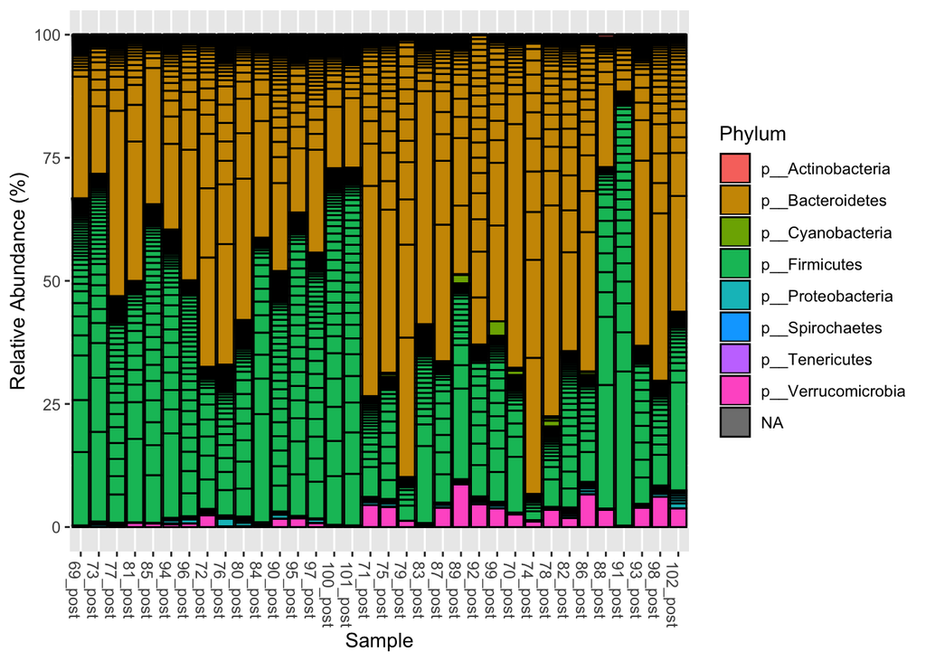

```r
phylo_pre_relab = transform_sample_counts(phylo_pre, function(x) 100 * x/sum(x))
phylo_post_relab = transform_sample_counts(phylo_post, function(x) 100 * x/sum(x))

# Taxa bar plots
# Phylum level
p = plot_bar(phylo_post_relab, fill="Phylum")
# Change the order of the samples on the x axis to be listed by experimental group. This was manually determined in the mapping file: "SortOrder"
p$data$Sample = as.character(p$data$Sample)  # "Sample" here is data-set specific. It's the dataframe column being plotted on X
p$data$Sample = factor(p$data$Sample, levels=desired_col_order)
p + ylab("Relative Abundance (%)")
```

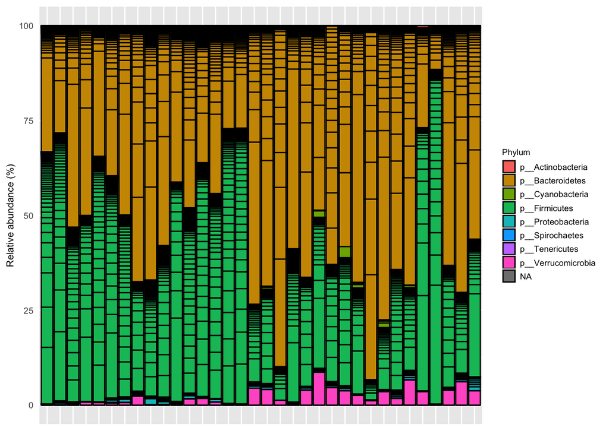

```r
ggsave("post_gavage_taxa_bargraph_phylum-ANNOTATED.pdf")
# Plot for publication.
p + theme(axis.text.x = element_blank(),  # Turn off tick label titles.
          axis.ticks = element_blank(),  # Turn off black tick marks.
          text = element_text(size=9),
          axis.title = element_text(size=8),
          axis.title.x = element_blank(),  # Turn off X axis label. Obvious that they're samples.
          legend.key.size = unit(4, "mm"),
          legend.text=element_text(size=7),
          legend.title=element_text(size=7)
          ) +
    ylab('Relative abundance (%)')
```

```r
ggsave("post_gavage_taxa_bargraph_phylum.pdf", width=170, height=45, units='mm')
```

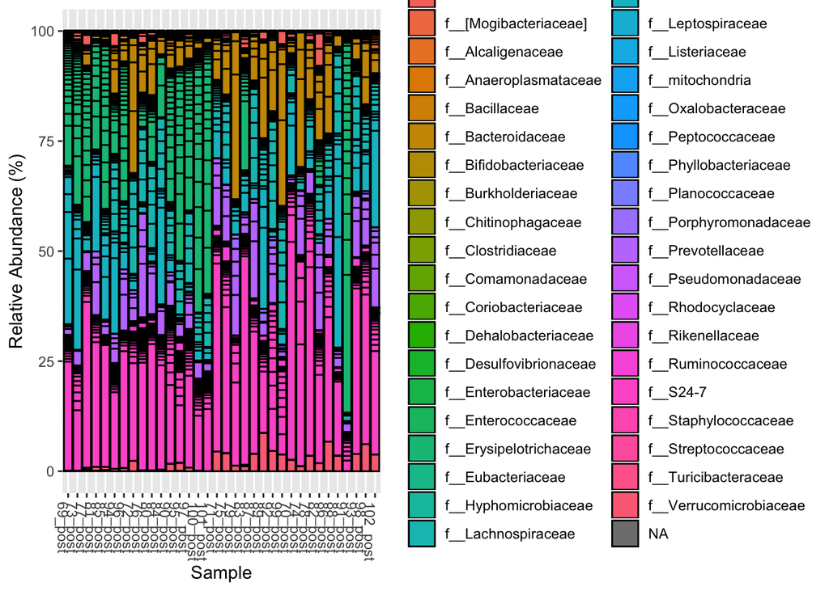

```r
# Family level
p = plot_bar(phylo_post_relab, fill="Family")
# Change the order of the samples on the x axis to be listed by experimental group. This was manually determined in the mapping file: "SortOrder"
p$data$Sample = as.character(p$data$Sample)  # "Sample" here is data-set specific. It's the dataframe column being plotted on X
p$data$Sample = factor(p$data$Sample, levels=desired_col_order)
p + ylab("Relative Abundance (%)")
```

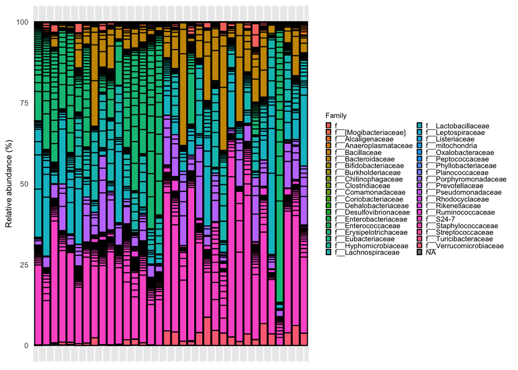

```r
ggsave("post_gavage_taxa_bargraph_family-ANNOTATED.pdf")
# Plot for publication.
p + theme(axis.text.x = element_blank(),  # Turn off tick label titles.
          axis.ticks = element_blank(),  # Turn off black tick marks.
          text = element_text(size=9),
          axis.title = element_text(size=8),
          axis.title.x = element_blank(),  # Turn off X axis label. Obvious that they're samples.
          legend.key.size = unit(2, "mm"),
          legend.text=element_text(size=7),
          legend.title=element_text(size=7)
          ) +
    ylab('Relative abundance (%)')
```

```r
ggsave("post_gavage_taxa_bargraph_family.pdf", width=180, height=60, units='mm')
```